# Revisiting the Box-Jenkins Method

FISH 507 – Applied Time Series Analysis

Eli Holmes

24 Jan 2019

Let’s imagine that we can describe our data as a combination of the mean trend and error.

$$x_t = m_t + e_t$$

What if our main goal is to predict $x_{t+1}$? Note we (fisheries biologists and ecologists) often want to know $m_t$. In fact, that is often our main and sole goal. But let’s say our goal is to predict $x_{t+1}$.

How do we do this?

# Approach #1 which we will use in the rest of the course

We estimate $m_t$ from the data. Once we have an estimate of $m_t$, we have an estimate of $e_t$. We can model that error (think AR and MA) to help us predict future $x_t$ from $x_{t-1}$.

Mark introduced filtering (moving averages) as one way to estimate $m_t$. We will not be doing that in the rest course. Instead, we will have a model for the $m_t$ and we will fit
$$x_t = m_t + e_t$$
directly. We will get an estimate of the model that produced $m_t$. We will also estimate the structure (think AR, MA) of $w_t$. **directly** means that we not be transforming our data with differencing in order to produce a statistic (difference) that is stationary. The $x_t$ and $m_t$ models will have a biological interpretation.

So for example if our model is

$$m_t = m_{t-1}+\mu \\ x_t = m_t +
w_t.$$
Then we fit that model without taking any differences. Note the above is a trivial example as it is just a linear deterministic trend but gives you the idea.

# Approach #2 Box-Jenkins

The Box-Jenkins approach is different. In this approach to predicting $x_{t+1}$, we remove $m_t$ from our data using differencing. We don’t have to worry about a model for $m_t$ because we have removed it!

And we don’t actually need it to predict $x_{t+1}$ since we have $x_{t}$, $x_{t-1}$, etc. We model $\Delta^d x_t$ and then predict $\Delta^d x_{t+1}$. $\Delta^d x_t$ is a d-th difference. Once we have that we can predict $x_{t+1}$ by using $x_t$, $x_{t-1}$, etc with some algebra.

The error structure of $\Delta^d x_{t+1}$ is NOT the same as $e_t$.
$$\Delta^d x_{t} = \phi_1\Delta^d x_{t-1} +
\phi_2\Delta^d x_{t-2} + \dots + z_t$$

$z_t$ is the error of the differences. And the $\phi$ in the AR part are for the differences not the original $x_t$. So it is more difficult to make a biological interpretation of the ARMA model. But remember, the objective was to predict $x_{t+1}$ not to fit a model with a biological interpretation.

## Examples of differencing, linear trend

$m_t$ is linear and deterministic.

$$x_t = \mu t + w_t$$

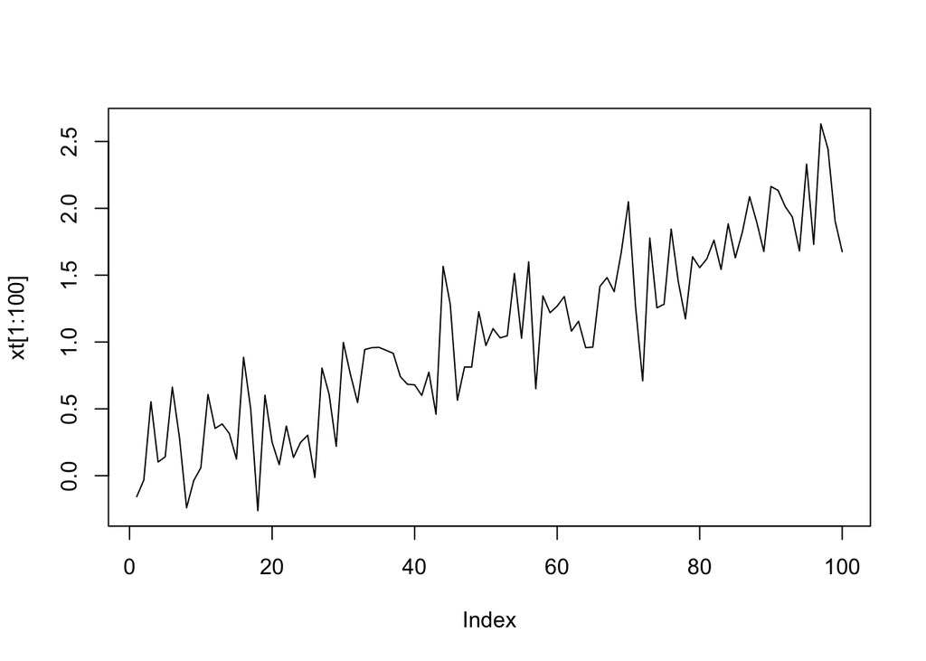

When we take the first difference, we get
$$\Delta x_t = \mu (t - (t-1)) + w_t - w_{t-1} =
\mu + w_t - w_{t-1}$$
So you expect that we should estimate a ARIMA(0,1,1) with drift. For some reason `auto.arima()` is returning Inf for the AICc for ARIMA(0,1,1) with drift although `Arima()` returns it. Turn on `trace=TRUE` to see the problem.

```r
forecast::auto.arima(xt, stepwise=FALSE)
```

```
## Series: xt
## ARIMA(0,1,3)
##
## Coefficients:
##           ma1      ma2     ma3
##       -0.7878  -0.1612  0.2303
## s.e.   0.1036   0.1496  0.1103
##
## sigma^2 = 0.1014:  log likelihood = -26.19
## AIC=60.39   AICc=60.81   BIC=70.77
```

But we can recover the parameters with `Arima()`. Notice that the AICc is much smaller than for the model chosen by `auto.arima()`.

```r
forecast::Arima(xt,order=c(0,1,1),include.drift=TRUE)
```

```
## Series: xt
## ARIMA(0,1,1) with drift
##
## Coefficients:
##           ma1   drift
##       -1.0000  0.0208
## s.e.   0.0295  0.0010
##
## sigma^2 = 0.0845:  log likelihood = -19.45
## AIC=44.9   AICc=45.16   BIC=52.69
```

## Examples of differencing, quadradic trend

$m_t$ is quadratic linear and deterministic.

$$x_t = \mu t^2 + w_t$$

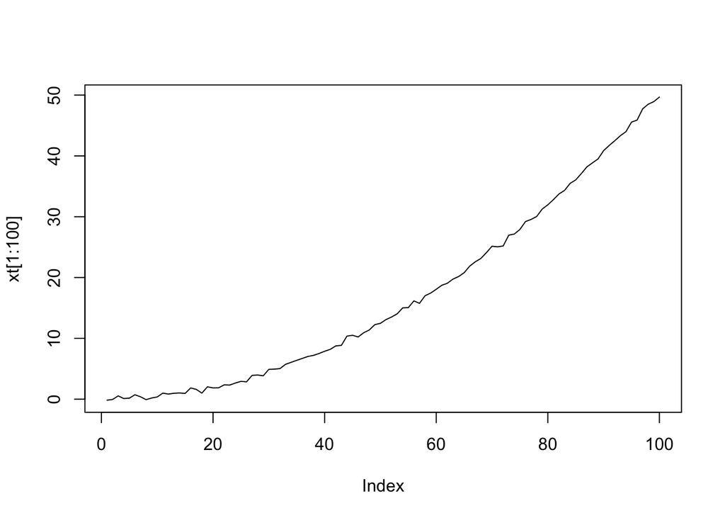

When we take the first difference, we get
$$\Delta x_t = \mu (t^2 - (t-1)^2) + w_t - w_{t-1}
= \mu(2t-1) + w_t - w_{t-1}$$
When we take another difference, and we get
$$\Delta^2 x_t
= 2\mu(2t-1-2(t-1)+1) + w_t - 2w_{t-1} + w_{t-2}$$
##

So you expect that we should estimate a ARIMA(0,2,2) with drift. Because `Arima()` will not estimate the drift term if we have a 2nd difference, I will fit to the first difference. And we recover the terms as expected.

```r
forecast::Arima(diff(xt),order=c(0,1,2), include.drift=TRUE)
```

```
## Series: diff(xt)
## ARIMA(0,1,2) with drift
##
## Coefficients:
##           ma1     ma2  drift
##       -1.9888  0.9888   0.01
## s.e.   0.0037  0.0035   0.00
##
## sigma^2 = 0.09959:  log likelihood = -272.92
## AIC=553.83   AICc=553.87   BIC=573.46
```

`auto.arima()` struggles however.

```r
forecast::auto.arima(diff(xt), stepwise=FALSE)
```

```
## Series: diff(xt)
## ARIMA(1,1,2) with drift
##
## Coefficients:
##          ar1      ma1     ma2  drift
##       0.0587  -1.9742  0.9744   0.01
## s.e.  0.0331   0.0083  0.0081   0.00
##
## sigma^2 = 0.1015:  log likelihood = -279.58
## AIC=569.15   AICc=569.21   BIC=593.68
```

## Examples of differencing, random walk trend

$m_t$ is a random walk.

$$x_t = m_t + w_t\\m_t =
m_{t-1}+v_t$$
When we take the first difference, we get
$$\Delta x_t = m_t - m_{t-1} + w_t - w_{t-1} = v_t
+ w_t - w_{t-1}$$
That’s a moving average ($w_t-w_{t+1}$) plus added white noise which is not an ARMA model. We can fit as a state-space model however.

# Seasonal models

We can take the same approach with a seasonal model. Let’s imagine that we can describe our data as a combination of the mean trend, a seasonal term, and error.

$$x_t = \mu t+ s_t + w_t$$
Let’s imagine that the seasonal term is just a constant based on month and doesn’t change with time.

$$s_t = f(month)$$
##

We want to remove the $s_t$ with differencing so that we can model $e_t$. We can solve for $x_{t+1}$ by using $x_{t-s}$ where $s$ is the seasonal length (e.g. 12 if season is yearly).

When we take the first seasonal difference, we get
$$\Delta_s x_t = \mu(t-(t-s)) + s_t - s_{t-s} + w_t
- w_{t-s} = \mu s + w_t - w_{t-s}$$
##

The $s_t-s_{t-s}$ disappears because $s_t = s_{t-s}$ when the seasonal effect is just a function of the month. Depending on what $m_t$ is, we might be done or we might have to do a first difference. Notice that the error term is a moving average in the seasonal part.

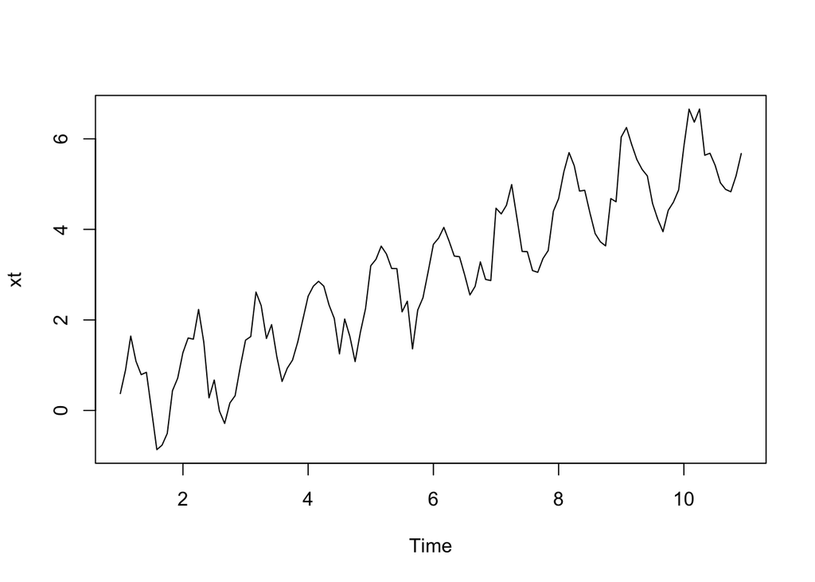

`auto.arima()` identifies a ARIMA(0,0,0)(0,1,2)[12].

```r
forecast::auto.arima(xt, stepwise=FALSE)
```

```
## Series: xt
## ARIMA(0,0,0)(0,1,2)[12] with drift
##
## Coefficients:
##          sma1    sma2   drift
##       -1.0488  0.1765  0.0496
## s.e.   0.1606  0.1148  0.0007
##
## sigma^2 = 0.08705:  log likelihood = -29.56
## AIC=67.12   AICc=67.51   BIC=77.85
```

But we can recover the model parameters with `Arima()`. Note the drift term is returned at $\mu$ not $\mu s$.

```r
forecast::Arima(xt, seasonal=c(0,1,1), include.drift=TRUE)
```

```
## Series: xt
## ARIMA(0,0,0)(0,1,1)[12] with drift
##
## Coefficients:
##          sma1   drift
##       -1.0000  0.0496
## s.e.   0.1845  0.0008
##
## sigma^2 = 0.08162:  log likelihood = -30.74
## AIC=67.49   AICc=67.72   BIC=75.53
```

## Seasonal model with changing season

Let’s imagine that our seasonality in increasing over time.

$$s_t = \beta \times year \times
f(month)\times$$
When we take the first seasonal difference, we get
$$\Delta_s x_t = \mu(t-(t-s)) + \beta
f(month)\times (year - (year-1)) + w_t - w_{t-s} \\ = \mu s + \beta
f(month) + w_t - w_{t-s}$$
We need to take another seasonal difference to get rid of the $f(month)$ which is not a constant; it is different for different months as it is our seasonality.
$$\Delta^2_{s} x_t = w_t - w_{t-s} - w_{t-s} +
w_{t-2s}=w_t - 2w_{t-s} + w_{t-2s}$$
So our ARIMA model should be ARIMA(0,0,0)(0,2,2)

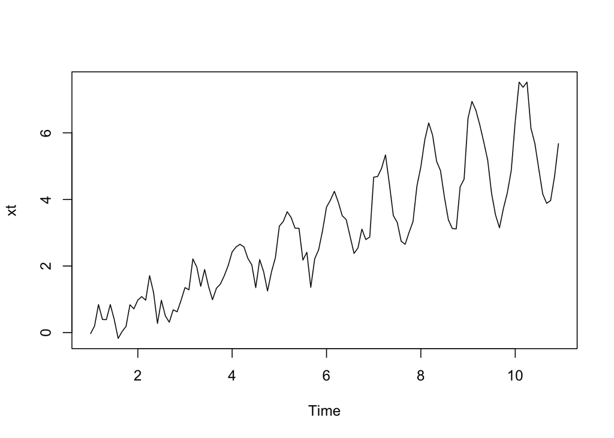

`auto.arima()` again has problems and returns many Infs; turn on `trace=TRUE` to see the problem.

```r
forecast::auto.arima(xt, stepwise=FALSE)
```

```
## Series: xt
## ARIMA(4,0,0)(1,1,0)[12] with drift
##
## Coefficients:
##          ar1      ar2     ar3      ar4     sar1   drift
##       0.2548  -0.0245  0.2166  -0.2512  -0.5393  0.0492
## s.e.  0.0945   0.0947  0.0943   0.0966   0.0868  0.0025
##
## sigma^2 = 0.1452:  log likelihood = -48.2
## AIC=110.41   AICc=111.53   BIC=129.18
```

```r
forecast::Arima(xt, seasonal=c(0,2,2))
```

```
## Series: xt
## ARIMA(0,0,0)(0,2,2)[12]
##
## Coefficients:
##          sma1    sma2
##       -1.7745  0.9994
## s.e.   0.4178  0.4624
##
## sigma^2 = 0.1045:  log likelihood = -55.1
## AIC=116.2   AICc=116.46   BIC=123.9
```

## Seasonal model with changing season #2

$$s_t = (a y^2-b y+h) f(month)$$

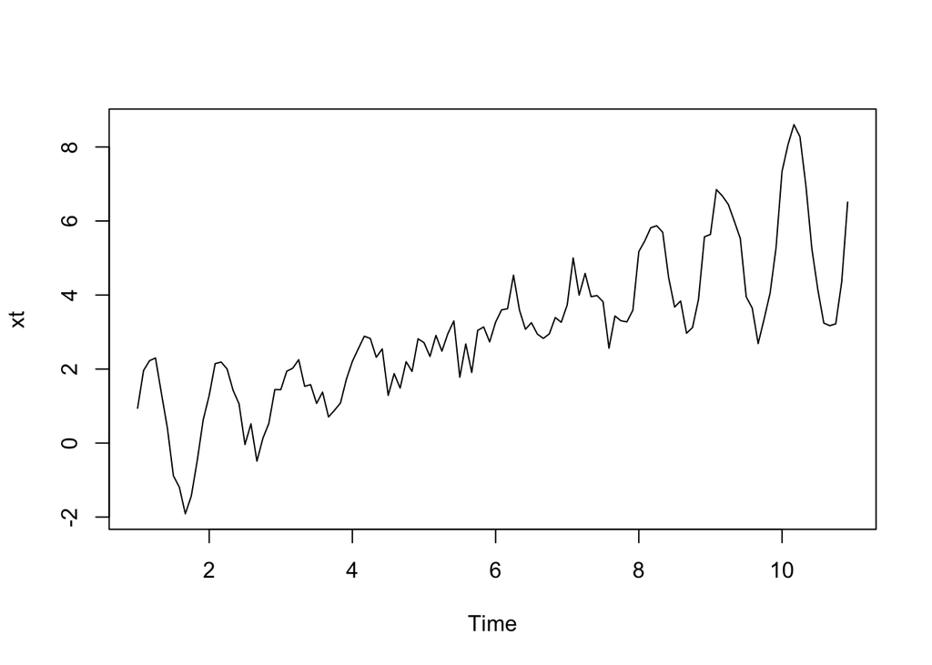

Then we need to take 3 seasonal differences to get rid of the seasonality. The first will get rid of the $h f(month)$, the next will get rid of $by$ (year) terms and $y^2$ terms, the third will get rid of extra $y$ terms introduced by the 2nd difference. The seasonal differences will get rid of the linear trend also.

$$\Delta^3_{s} x_t = w_t - 2w_{t-s} +
w_{t-2s}-w_{t-s}+2w_{t-2s}-w_{t-3s}=w_t - 3w_{t-s} +
3w_{t-2s}-w_{t-3s}$$

So our ARIMA model should be ARIMA(0,0,0)(0,3,3).

`auto.arima()` again has problems and returns many Infs; turn on `trace=TRUE` to see the problem.

```r
forecast::auto.arima(xt, stepwise=FALSE)
```

[output not shown]

But we can recover the model parameters, more or less, with `Arima()`.

```r
forecast::Arima(xt, seasonal=c(0,3,3))
```

```
## Series: xt
## ARIMA(0,0,0)(0,3,3)[12]
##
## Coefficients:
##          sma1    sma2     sma3
##       -2.6782  2.4882  -0.7888
## s.e.   2.4097  4.1892   1.9930
##
## sigma^2 = 0.1542:  log likelihood = -94.67
## AIC=197.34   AICc=197.85   BIC=207.06
```